# Machine-Learning-vol.02-単回帰分析

## 2.6 モデルの解釈と利用法

学習が終わったところで､**回帰直線の方程式の意味**を読み解いていきましょう｡実は､求められた回帰式は重要な示唆を含んでおり､ただ求めて終わりにしてしまうのは､非常にもったいないことです｡まずは､**パラメータの $w_0$ と $w_1$ が､学習によりどのような値に決まったのかを調べてみましょう**｡

[figure not shown]

### 回帰式の解釈

#### 定数項 $w_0$

最初に確認するのは､**定数項 $w_0$** です｡$w_0$ は､**$y$ 軸の切片(intercept)**ということで､学習させたインスタンスの intercept_ に格納されています｡ちなみに､名称の末尾にアンダーバーが入っているのは､**｢これは学習によって得られた推測値である｣**という意味です｡パラメータの中には分析者が事前に値を指定するものもあるので､それとの区別をしています｡

```python
# 定数項を確認
lr.intercept_
```

```
array([ 28.68469012])
```

#### $x_1$の係数 $w_1$

次に､**$x_1$ の係数 $w_1$** を確認します｡$w_1$ は**説明変数の係数(coefficient)**ということで､インスタンスの **coef_** に格納されています｡

```python
# 係数を確認
lr.coef_
```

```
array([[ 4.31834154]])
```

以上の結果から､**回帰直線の方程式**は以下のようになっていることがわかりました｡

$$\begin{align} y &= w_0x_0 + w_1x_1\\ &= 28.68 + 4.32x_1 \end{align}$$

#### 数式的な解釈

[figure not shown]

このようにして､**回帰式からモデルの意味が読み取れます**｡本来､モデルとは**現実の構造を数式で構造化したもの**なので､このようなことが読み取れます｡データをもとに学習させることによって､現実に対する深い洞察が得られるのです｡

#### グラフによる確認

**視覚的にもこの式の妥当性を確認するために**､**この回帰直線を散布図上にプロットしてみましょう**｡回帰直線は**最小二乗法**の結果として得られたものですから､**データに対して当て､最もはまりの良い直線になっているはずです**｡それを確認してみましょう｡

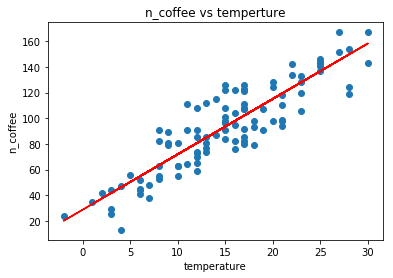

```python
# 散布図に近似直線を重ねてみる
plt.scatter(X, y)                       # 散布図を表示
plt.plot(X, lr.predict(X), color='red') # 回帰直線を表示
plt.title('n_coffee vs temperture')     # グラフのタイトルを表示
plt.xlabel('temperature')               # x軸のラベルを表示
plt.ylabel('n_coffee')                  # y軸のラベルを表示
plt.show()                              # 上記の内容でグラフを表示
```

### 回帰式の利用

さて､ここまでで**求めたかった回帰式がちゃんと得られたことが確認できました**｡それではいよいよ､**得られた回帰式を使ってアイスコーヒーの売上個数を予測してみましょう**｡**天気予報**で得られた一週間後の最高気温 new_temp を仮定して､対応する売上個数 n_pred を算出します｡

[figure not shown]

```python
# その日の気温を入力
new_temp = 30

# その日のアイスコーヒーの売上個数を予測
n_pred = lr.predict(new_temp)
print(n_pred)
```

```
[[ 158.23493644]]
```

回帰分析の結果によると､どうやら**気温が30℃の日はアイスコーヒーが約158個売れるそうです**｡

こうすれば､今後この喫茶店のオーナーは､天気予報でその先一週間の気温から毎日の売上個数を予測して**､一週間分の必要な材料の量がわかります**｡これによって､**過不足のない仕入れ量を注文することが出来ます**｡

## 2.7 利用上の注意点

無事に回帰分析を利用して目標を達成できたわけですが､最後に**実用の上での注意点**について解説をしたいと思います｡ここまで押さえられると､実際の分析でも深い考察が出来るはずです｡

### 1. 因果関係と共変関係の違い

データの観察の段階で**相関係数**をチェックしましたが､実は相関関係が強いときには**2通りのパターン**があります｡ひとつは**因果関係**が成り立っているパターン､もう一つは**共変関係**が成り立っているパターンです｡データ分析では､この2つを明確に区別すること､さらに言えば**共変関係を因果関係と取り違えないこと**が非常に重要です｡

[figure not shown]

#### 因果関係

まず､因果関係とは､**一方の出来事が､もう一方の出来事を引き起こす**という､**原因と結果の関係**です｡たとえば､**最高気温とアイスコーヒーの売上個数の関係**は因果関係に該当します｡｢気温が高い｣という出来事は､｢コーヒーが多く売れる｣という出来事を引き起こします｡しかし､**逆に｢コーヒーが多く売れる｣という出来事が､｢気温が高い｣という出来事を引き起こすことはありません**｡つまり､**｢気温が上がれば､コーヒーが売れる｣**は成り立つのですが､**｢コーヒーが売れれば､気温が上がる｣**は成り立たないのです｡このように､**2つの出来事の順序に縛りがある**ことがポイントです｡

#### 共変関係

一方､共変関係とは､**2つの出来事がどちらからともなく同時に起こる**という､**結果と結果の関係**です｡例えば､**身長や体重の関係**などが共変関係に該当します｡｢身長が高い｣､｢体重が重い｣という出来事は､**一方がもう一方を引き起こすと言うよりは､どちらからともなく同時に起こります**｡むしろ､**遺伝や生活習慣などの第三の要因が原因となり､｢身長が高い｣と｢体重が重い｣はどちらもその結果となっていること**が想定されます｡

このとき気をつけなければならないのは､**因果関係だけでなく､共変関係が成り立っているときでも､相関関係は成り立ってしまうという**ということです｡両者の違いを捉えるためには､**散布図や相関係数を見るだけではだめで**､出来事同士の関係性を本質的に捉えるだけの深い知識や思考力が求められます｡

### 2. 線形外挿の危険性

学習させた回帰式を用いて予測を行うときは､**必ずデータが取れた周辺の入力に対してのみ､結果を信頼するようにしましょう**｡なぜなら､**散布図で観察される直線的な関係性は､部分的にしか成立していないことがあるからです**｡また､このように**観測されたデータの直線の延長線上でも法則が成り立つと仮定してモデルを拡張すること**を**線形外挿**といいます｡下の図を見てもらえるとイメージが掴みやすいかと思います｡

[figure not shown]

左の図を見ると､2つの変数は**直線的な関係**があるように見えます｡回帰直線がちゃんとデータ点に当てはまっています｡しかし､このとき**データをより広い範囲で取ったら､実は右図のように曲線的な関係があって､その一部が直線的に見えていただけだったことが判明するケースもあるのです**｡相関係数も､左図にあるような一部のデータで取ったときは十分大きな値が得られます｡そういった理由から､**回帰分析は､データが得られた周辺の入力に対してしか､予測が信頼できないのです**｡

## 2.8 その他のストーリー

お疲れさまでした｡機械学習の1つめの手法である単回帰分析はいかがでしたでしょうか？

この章はここで終了ですが､重要なのは手法について覚えることではなく､**みなさんが実際に､自身の仕事や研究にこうした手法を活用すること**です｡単回帰分析はシンプルではありますが､様々な場面で利用できます｡たとえば､以下に示すようなケースでも役に立つことが見込まれます｡みなさんも､相関関係が強い2つの出来事を挙げて､データが手に入れば実際に分析をしてみましょう｡

#### 単回帰分析の活用が見込まれるケース

- 研究開発費の金額から､IT企業の株価を予測する
- 広告費から､イベントの来場人数を予測する
- エンジンサイズから､車の価格を予測する
- 駅からの距離から､家賃を予測する
- 町の総人口と警察官人数の比から､月間の犯罪発生件数を予測する

[figure not shown]

監修: 東京女子大学情報処理センター 浅川伸一